# R Notebook

Component 3

steps:importing data removing null values removing outliers scaling the data to normalize the data Verifying all data points in each field are of same format

```r
library(dplyr)
library(ggplot2)
library(readxl)
library(lubridate)
library(caret)
setwd("G:/LILTHOMA/Rise_Wpu/Mentor_Mind/Identify_customer_segments_for_online_retail_using_K-means")
customer_data <- read_excel("Online Retail.xlsx")
View(customer_data)

null_values <- colSums(is.na(customer_data))
```

```r
null_df <- data.frame(null_values)
print(sum(duplicated(customer_data)))
```

```
[1] 5268
```

```r
null_df%>%mutate(percentage=null_values/nrow(customer_data))
```

|  | null_values | percentage |
| --- | --- | --- |
| InvoiceNo | 0 | 0.000000000 |
| StockCode | 0 | 0.000000000 |
| Description | 1454 | 0.002683107 |
| Quantity | 0 | 0.000000000 |
| InvoiceDate | 0 | 0.000000000 |
| UnitPrice | 0 | 0.000000000 |
| CustomerID | 135080 | 0.249266943 |
| Country | 0 | 0.000000000 |

```r
NA
```

#CustomerID has 24% data missing and Description has less than 1% missing values #5268 duplicated values are present

```r
clean_df <- customer_data%>%
  filter_all(all_vars(!is.na(.)))
removed_data <- customer_data%>%
  filter_all(any_vars(is.na(.)))
clean_df
```

| InvoiceNo | StockCode | Description | Quantity | InvoiceDate | UnitPrice | CustomerID | Country |
| --- | --- | --- | --- | --- | --- | --- | --- |
| 536365 | 85123A | WHITE HANGING HEART T-LIGHT HOLDER | 6 | 2010-12-01 08:26:00 | 2.55 | 17850 | United Kingdom |
| 536365 | 71053 | WHITE METAL LANTERN | 6 | 2010-12-01 08:26:00 | 3.39 | 17850 | United Kingdom |
| 536365 | 84406B | CREAM CUPID HEARTS COAT HANGER | 8 | 2010-12-01 08:26:00 | 2.75 | 17850 | United Kingdom |
| 536365 | 84029G | KNITTED UNION FLAG HOT WATER BOTTLE | 6 | 2010-12-01 08:26:00 | 3.39 | 17850 | United Kingdom |
| 536365 | 84029E | RED WOOLLY HOTTIE WHITE HEART. | 6 | 2010-12-01 08:26:00 | 3.39 | 17850 | United Kingdom |
| 536365 | 22752 | SET 7 BABUSHKA NESTING BOXES | 2 | 2010-12-01 08:26:00 | 7.65 | 17850 | United Kingdom |
| 536365 | 21730 | GLASS STAR FROSTED T-LIGHT HOLDER | 6 | 2010-12-01 08:26:00 | 4.25 | 17850 | United Kingdom |
| 536366 | 22633 | HAND WARMER UNION JACK | 6 | 2010-12-01 08:28:00 | 1.85 | 17850 | United Kingdom |
| 536366 | 22632 | HAND WARMER RED POLKA DOT | 6 | 2010-12-01 08:28:00 | 1.85 | 17850 | United Kingdom |
| 536367 | 84879 | ASSORTED COLOUR BIRD ORNAMENT | 32 | 2010-12-01 08:34:00 | 1.69 | 13047 | United Kingdom |

[output cut: 990 more lines]

```r
#Removing Duplicates
final_df <-distinct(clean_df)
print(sum(duplicated(final_df)))
```

```
[1] 0
```

```r
final_df$month <-month(final_df$InvoiceDate)
summary(final_df$month)
```

```
   Min. 1st Qu.  Median    Mean 3rd Qu.    Max.
  1.000   5.000   8.000   7.595  11.000  12.000
```

```r
#finding outliers UnitPrice

q1_price <- quantile(final_df$UnitPrice,0.25,na.rm=T)
q3_price <-quantile(final_df$UnitPrice,0.75,na.rm=T)
iqr<-q3_price - q1_price
lower_bound_price = q1_price - 1.5*iqr
upper_bound_price =q3_price + 1.5*iqr
outliers <- final_df$UnitPrice[final_df$UnitPrice < lower_bound_price | final_df$UnitPrice > upper_bound_price]
final_df$UnitPrice <- ifelse(final_df$UnitPrice %in% outliers, NA, final_df$UnitPrice)
```

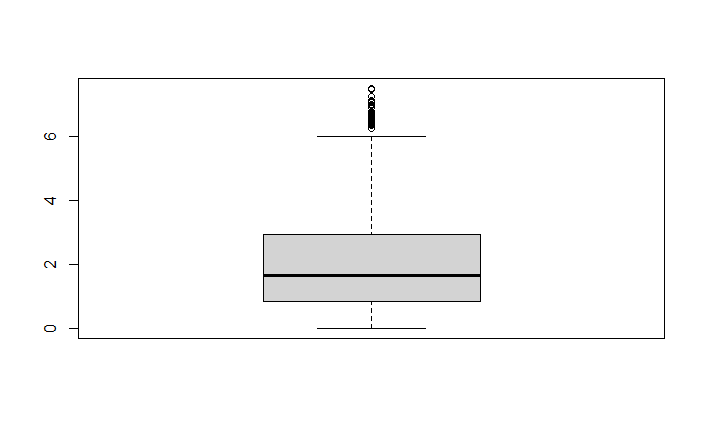

```r
boxplot(final_df$UnitPrice)
```

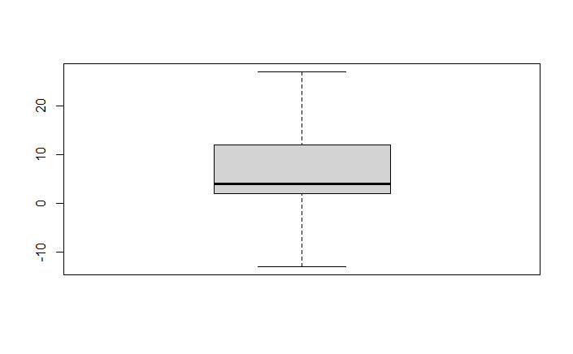

```r
#finding outliers Quantity

q1_quant <- quantile(final_df$Quantity,0.25,na.rm=T)
q3_quant <-quantile(final_df$Quantity,0.75,na.rm=T)
iqr<-q3_quant - q1_quant
lower_bound_quant = q1_quant - 1.5*iqr
upper_bound_quant =q3_quant + 1.5*iqr
outliers_quant <- final_df$Quantity[final_df$Quantity < lower_bound_quant | final_df$Quantity > upper_bound_quant]
final_df$Quantity <- ifelse(final_df$Quantity %in% outliers_quant, NA, final_df$Quantity)
boxplot(final_df$Quantity)
```

```r
sum(is.na(final_df))
```

```
[1] 62448
```

```r
new_data <- final_df%>%filter_all(all_vars(!is.na(.)))
sum(is.na(new_data))
```

```
[1] 0
```

```r
print(new_data%>%group_by(CustomerID)%>%count()%>%arrange(-n)%>%head(30))
```

| CustomerID | n |
| --- | --- |
| 17841 | 7327 |
| 14911 | 4635 |
| 14096 | 4416 |
| 12748 | 4069 |
| 14606 | 2496 |
| 15311 | 2011 |
| 13263 | 1614 |
| 13089 | 1536 |
| 15039 | 1265 |
| 18118 | 1199 |

[output cut: 20 more lines]

```r
new_data%>%group_by(StockCode)%>%count()%>%arrange(-n)%>%head(30)
```

| StockCode | n |
| --- | --- |
| 85123A | 1712 |
| 85099B | 1363 |
| 47566 | 1283 |
| 20725 | 1232 |
| 22720 | 1183 |
| 84879 | 1155 |
| 20727 | 1040 |
| 22383 | 1022 |
| 23203 | 1002 |
| 23298 | 988 |

[output cut: 20 more lines]

```r
new_data%>%group_by(InvoiceNo)%>%count()%>%arrange(-n)%>%head(30)
```

| InvoiceNo | n |
| --- | --- |
| 576339 | 460 |
| 579196 | 450 |
| 580727 | 442 |
| 573576 | 384 |
| 567656 | 370 |
| 578270 | 369 |
| 567183 | 353 |
| 575607 | 328 |
| 571441 | 316 |
| 572552 | 310 |

[output cut: 20 more lines]

```r
sum(duplicated(new_data))
```

```
[1] 0
```

#We have finished the data preperation process 1)removed null values 2)extracted month values 3)removed outiers from the data

#My thoughts & Further process * invoice number stock code and customer Id are the unique fields and is not benefical for this clustering still i am going to clean the inconsistencies in these fields

*Conduct a EDA before going on towards RFM analysis to understand the trends

- I am familiar with RFM analysis a marketing technique for customer segementation so i am going to create some features for Recency Frequency and monetary and a combiation of these is RFM value

*Correct Skewness in the data

*Conduct EDA on RFM data Answer some key questions then to standardise and clustering

*To identify the features of customers in each of Clusters

```r
#library(stringr)
#new_data$StockCode <- trimws(str_replace(new_data$StockCode, "[A-Za-z]$", ""))
#new_data$StockCode <- as.numeric(new_data$StockCode)
#new_data$InvoiceNo <- trimws(str_replace(new_data$InvoiceNo, "[A-Za-z]$", ""))
#new_data$InvoiceNo <- as.numeric(new_data$InvoiceNo)
#str(new_data)
```

Above Codes has been commented out because it indroduces a lot of NA values and we are not going to use those columns for clustering

```r
#Final cleaned values with no inconsistent data formats and no null or duplicate values
#Quantity column contains negative values which should be removed to actually have sensible data
cleaned_data <-new_data%>%filter_all(all_vars(!is.na(.)))
sum(is.na(cleaned_data))
```

```
[1] 0
```

```r
cleaned_data <- cleaned_data%>%filter(Quantity > 0)
#Creating Revenue column
cleaned_data$revenue <- cleaned_data$UnitPrice * cleaned_data$Quantity
```

#EDA

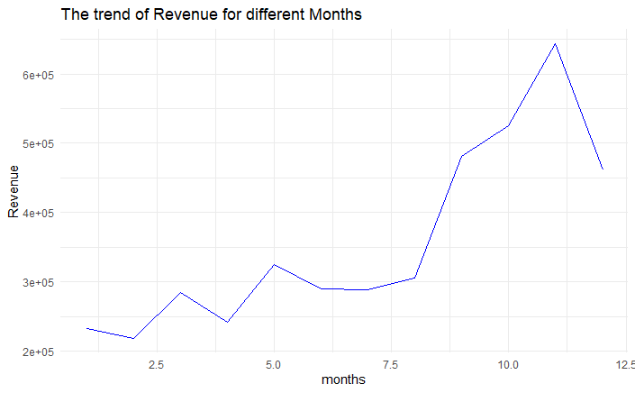

```r
monthly_revenue <- cleaned_data%>%group_by(month)%>%summarise(sum=sum(revenue))
ggplot(data=monthly_revenue,aes(x=month,y=sum))+
  geom_line(color="Blue")+
  labs(title="The trend of Revenue for different Months",x="months",y="Revenue")+
  theme_minimal()
```

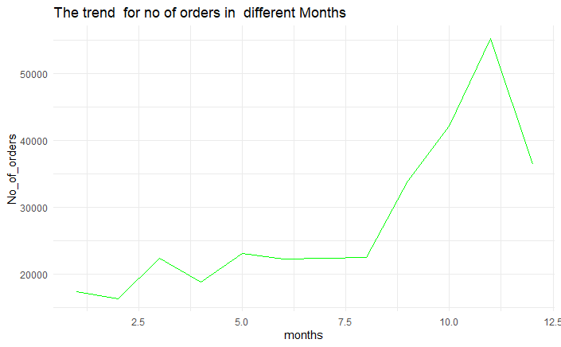

```r
monthly_orders <- cleaned_data%>%group_by(month)%>%summarise(sum=n())
ggplot(data=monthly_orders,aes(x=month,y=sum))+
  geom_line(color="green")+
  labs(title="The trend  for no of orders in  different Months",x="months",y="No_of_orders")+
  theme_minimal()
```

```r
#Is there any seasonal customers in our data because we can see that from the months
#August to November there is a significant rise in orders which result in more revenue
cleaned_data%>%group_by(CustomerID,month)%>%count()
```

| CustomerID | month | n |
| --- | --- | --- |
| 12347 | 1 | 28 |
| 12347 | 4 | 21 |
| 12347 | 6 | 16 |
| 12347 | 8 | 19 |
| 12347 | 10 | 42 |
| 12347 | 12 | 40 |
| 12348 | 1 | 1 |
| 12348 | 4 | 1 |
| 12348 | 12 | 4 |
| 12349 | 11 | 58 |

[output cut: 990 more lines]

```r
#Lets Not take month into consideration not because we can surely see a uptrend from months of august to november because they may just a seasonal trend  But we cannot also just neglect the fact that buying power of customers are most high in these months but for our purpose currently it not required
```

#Feature Engineering

```r
summary(cleaned_data)
```

```
  InvoiceNo          StockCode         Description           Quantity       InvoiceDate                       UnitPrice
 Length:333265      Length:333265      Length:333265      Min.   : 1.000   Min.   :2010-12-01 08:26:00.00   Min.   :0.000
 Class :character   Class :character   Class :character   1st Qu.: 2.000   1st Qu.:2011-04-08 09:54:00.00   1st Qu.:1.250
 Mode  :character   Mode  :character   Mode  :character   Median : 6.000   Median :2011-08-03 12:06:00.00   Median :1.650
                                                          Mean   : 7.551   Mean   :2011-07-12 13:42:03.54   Mean   :2.194
                                                          3rd Qu.:12.000   3rd Qu.:2011-10-23 12:08:00.00   3rd Qu.:2.950
                                                          Max.   :27.000   Max.   :2011-12-09 12:50:00.00   Max.   :7.500
   CustomerID      Country              month           revenue
 Min.   :12347   Length:333265      Min.   : 1.000   Min.   :  0.00
 1st Qu.:13988   Class :character   1st Qu.: 5.000   1st Qu.:  3.90
 Median :15235   Mode  :character   Median : 9.000   Median : 10.14
 Mean   :15319                      Mean   : 7.656   Mean   : 12.90
 3rd Qu.:16814                      3rd Qu.:11.000   3rd Qu.: 17.40
 Max.   :18287                      Max.   :12.000   Max.   :178.80
```

```r
#Recency I will take difference in days from last date of purchase in this dataset
#Frequency :Here the largest values are given score of 1 and d
#Monetary :here also the largest values are ranked one
#These ranking will be based on the Quatile values
last_date <- min(cleaned_data$InvoiceDate)
recency_df <- cleaned_data%>%group_by(CustomerID)%>%summarise(Last_purchase=max(InvoiceDate))
recency_df$Recency <- round(difftime(recency_df$Last_purchase,last_date,units = "days"))
recency_df <- recency_df[,c(1,3)]
recency_df$Recency =as.numeric(recency_df$Recency)


freq_monetary_df <-cleaned_data%>%group_by(CustomerID)%>%
  summarise(monetary = sum(revenue),freq = n())

rfm_table <- inner_join(recency_df,freq_monetary_df,by="CustomerID")
summary(rfm_table)
```

```
   CustomerID       Recency       monetary            freq
 Min.   :12347   Min.   :  0   Min.   :    0.0   Min.   :   1.0
 1st Qu.:13809   1st Qu.:230   1st Qu.:  206.1   1st Qu.:  14.0
 Median :15280   Median :323   Median :  465.8   Median :  36.0
 Mean   :15290   Mean   :281   Mean   : 1025.6   Mean   :  79.5
 3rd Qu.:16770   3rd Qu.:356   3rd Qu.: 1127.0   3rd Qu.:  87.0
 Max.   :18287   Max.   :373   Max.   :84980.9   Max.   :7209.0
```

# We have so far created a column for monetary frequency and Recency Now we will asssign scores for these using some basic logic and created RFM value which basically is the concatenation of

Recency Score + Frequency Score +Monetary Score ex : 1 + 2+ 4 = 124 # This is not addition this is concatenation

```r
rfm_table$Recency_score <- if_else(rfm_table$Recency < 230 ,1,
                                   if_else(rfm_table$Recency < 323 ,2,
                                           if_else(rfm_table$Recency <356 ,3,4)))
rfm_table$Freq_score <- if_else(rfm_table$freq > 87 ,1,
                                if_else(rfm_table$freq >36,2,
                                        if_else(rfm_table$freq > 14 ,3,4)))
rfm_table$Monetary_score <- if_else(rfm_table$monetary > 1126 ,1,
                                    if_else(rfm_table$monetary >466 ,2,
                                            if_else(rfm_table$monetary > 206 ,3,4)))
#Here use sep="" inside paste function to avoid NAs during corecion
rfm_table$rfm_value <- as.numeric(paste(rfm_table$Recency_score,rfm_table$Freq_score,rfm_table$Monetary_score,sep=""))
View(rfm_table)
```

RFM segmentation readily shows customer for any business like Best Customers, Loyal Customer, Customers on the verge of losing, Highest revenue-generating customers etc.

```r
print(paste("Best Customer :" ,rfm_table%>%filter(rfm_value ==111)%>%count()))
```

```
[1] "Best Customer : 26"
```

```r
print(paste("Loyal Customer :" ,rfm_table%>%filter(Freq_score==1)%>%count()))
```

```
[1] "Loyal Customer : 1039"
```

```r
print(paste("Big Spenders :" ,rfm_table%>%filter(Monetary_score==1)%>%count()))
```

```
[1] "Big Spenders : 1049"
```

```r
print(paste("Risk of Loosing :" ,rfm_table%>%filter(rfm_value==134)%>%count()))
```

```
[1] "Risk of Loosing : 85"
```

```r
print(paste("Lost best customers :" ,rfm_table%>%filter(rfm_value==411)%>%count()))
```

```
[1] "Lost best customers : 432"
```

```r
print(paste("Lost Cheap Customer :" ,rfm_table%>%filter(rfm_value==444)%>%count()))
```

```
[1] "Lost Cheap Customer : 76"
```

```r
#like this we can make out a lot of categories from RFM value
```

#Before using k-means to the data we have to make sure that

Data’s distribution is not skewed  
Data is standardised (i.e. mean of 0 and standard deviation of 1).

You can use log transformation or min max scaling of R package to normalise your data here i am using log

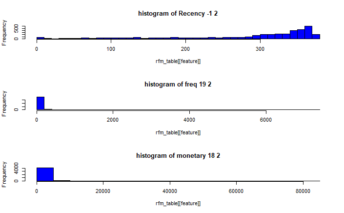

```r
library(moments)
#Visualising the distributions
feature_cols <- c("Recency","freq","monetary")

par(mfrow=c(3,1))
for (feature in feature_cols){
  hist(rfm_table[[feature]],col="blue",border="black",breaks = 30,main = paste("histogram of",feature,round(skewness(rfm_table[[feature]])),2))
}
par(mfrow=c(3,1))
```

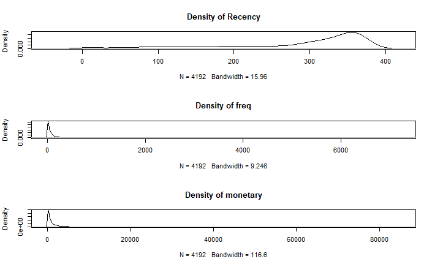

```r
for (feature in feature_cols){
  plot(density(rfm_table[[feature]]),main = paste("Density of",feature))
}
```

```r
# Selecting columns for clustering
names(rfm_table)
```

```
[1] "CustomerID"     "Recency"        "monetary"       "freq"           "Recency_score"  "Freq_score"     "Monetary_score"
[8] "rfm_value"
```

```r
data_for_clustering <- rfm_table[,c(1:4)]

#We will only transform monetary and frequency to reduce skewness

data_for_clustering$freq    <- log(data_for_clustering$freq+1)
data_for_clustering$monetary    <- log(data_for_clustering$monetary+1)


print(skewness(rfm_table[,1:4]))
```

```
  CustomerID      Recency     monetary         freq
 0.005145209 -1.244874316 17.564874327 18.947535517
```

```r
print(skewness(data_for_clustering))
```

```
  CustomerID      Recency     monetary         freq
 0.005145209 -1.244874316 -0.121313335  0.041173396
```

```r
new_rfm_table <-data_for_clustering
```

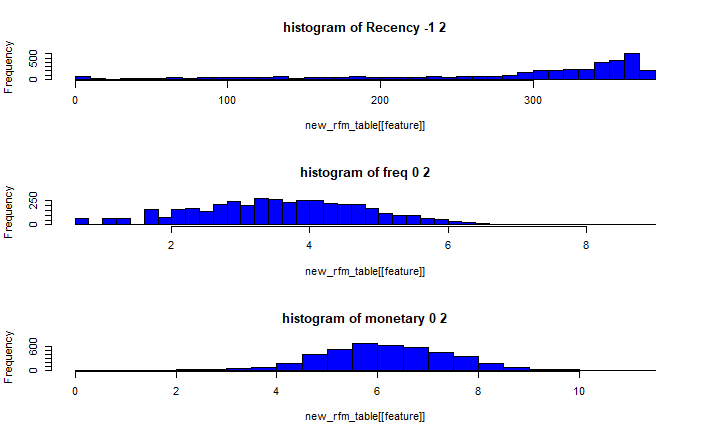

```r
par(mfrow=c(3,1))
for (feature in feature_cols){
  hist(new_rfm_table[[feature]],col="blue",border="black",breaks = 30,main = paste("histogram of",feature,round(skewness(new_rfm_table[[feature]])),2))
}
par(mfrow=c(3,1))
```

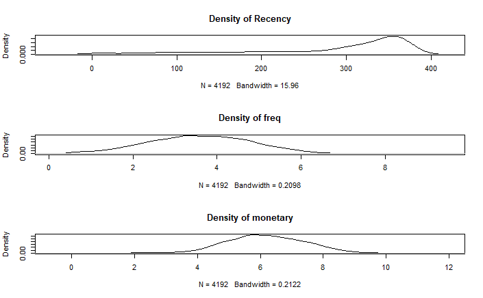

```r
for (feature in feature_cols){
  plot(density(new_rfm_table[[feature]]),main = paste("Density of",feature))
}
```

```r
# Define preprocessing steps (centering scaling)
preprocess_params <- preProcess(new_rfm_table[, -1], method = c("scale","center"))

# Apply centering and scaling to the data
normalized_scaled_data <- predict(preprocess_params, newdata = new_rfm_table )

final_data <- normalized_scaled_data
selected_df_scaled <-normalized_scaled_data
```

```r
library(factoextra)
selected_df <- selected_df_scaled
find_k <-selected_df[,-1]
set.seed(123)
sample_indices <- sample(nrow(find_k), size = 1000)  # You can adjust the sample size as needed
sample_data <- find_k[sample_indices, ]

# Convert the sample data to a matrix
sample_matrix <- as.matrix(sample_data)

# Compute the number of clusters using the within-cluster sum of squares (wss)
wss <- fviz_nbclust(sample_matrix, kmeans, method = "wss")
gap_stat <- fviz_nbclust(sample_matrix, kmeans, method = "gap_stat")
```

```
Clustering k = 1,2,..., K.max (= 10): .. done
Bootstrapping, b = 1,2,..., B (= 100)  [one "." per sample]:
.................................................. 50
.................................................. 100
```

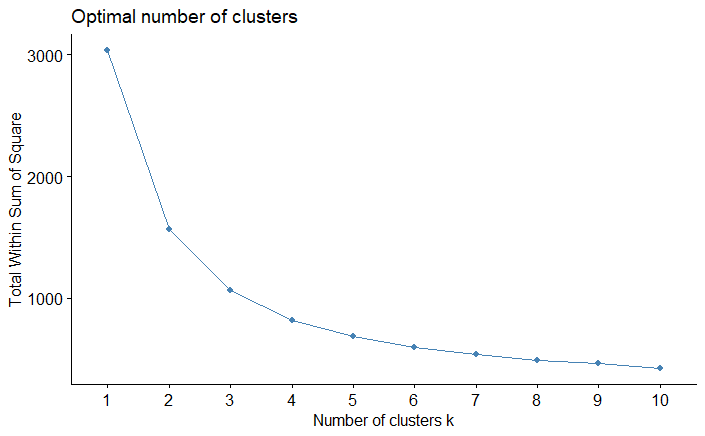

```r
silhouette <- fviz_nbclust(sample_matrix, kmeans, method = "silhouette")

# Print the result
print(wss)
```

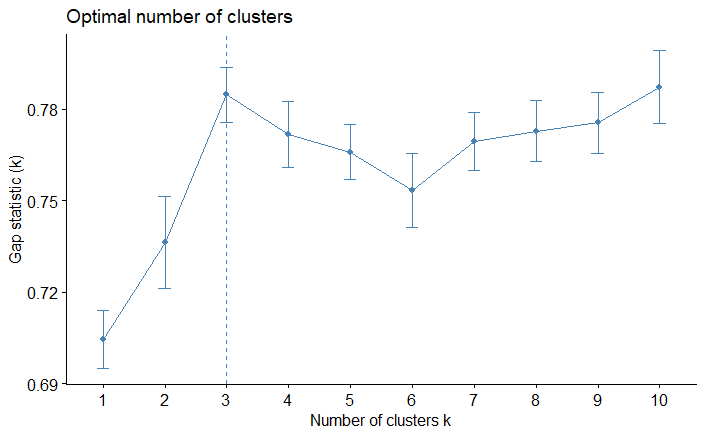

```r
print(gap_stat)
```

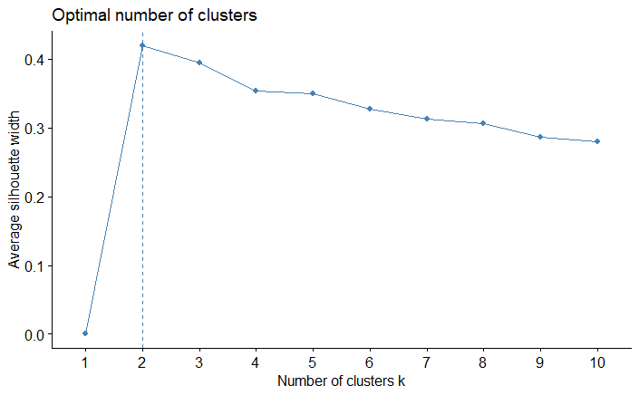

```r
print(silhouette)
```

```r
km3 <- kmeans(selected_df_scaled[,-1],iter.max = 100,centers = 3,nstart = 10)
km4 <- kmeans(selected_df_scaled[,-1],iter.max = 100,centers = 4,nstart = 10)
km5 <- kmeans(selected_df_scaled[,-1],iter.max = 100,centers = 5,nstart = 10)
km3
```

[output not shown]

```r
km4
```

[output not shown]

```r
km5
```

[output not shown]

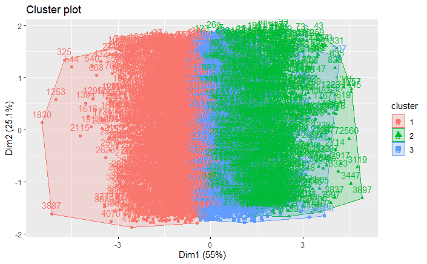

```r
fviz_cluster(list(data = selected_df_scaled,cluster=km3$cluster))
```

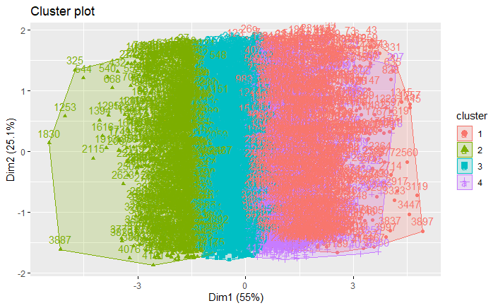

```r
fviz_cluster(list(data = selected_df_scaled,cluster=km4$cluster))
```

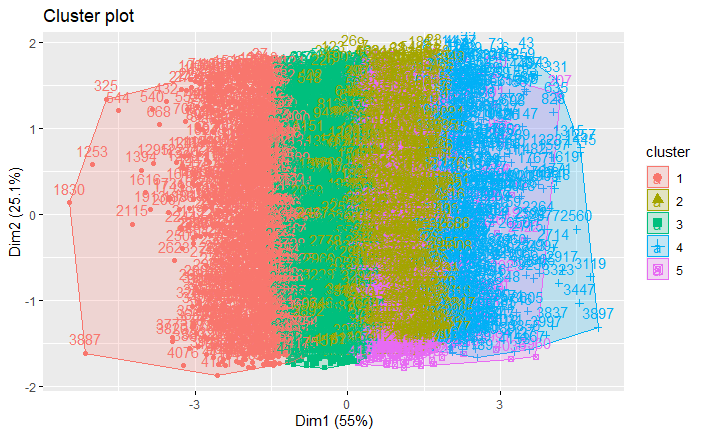

```r
fviz_cluster(list(data = selected_df_scaled,cluster=km5$cluster))
```

```r
NA
NA
```

[figure not shown]

The Bar graph above is not making much of a Sense A Snake Plot will be able to answer the questions we need

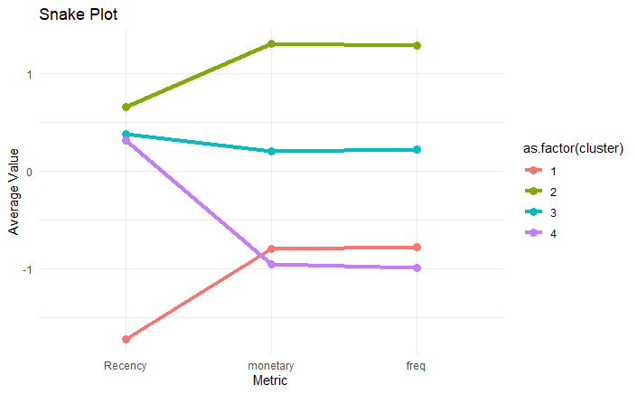

```r
library(dplyr)

# Calculate average values for each metric within each cluster
avg_values <- df_melt %>%
  group_by(cluster, metric) %>%
  summarise(avg_value = mean(value)) %>%
  ungroup()
# Create the snake plot
ggplot(avg_values, aes(x = metric, y = avg_value, color = as.factor(cluster))) +
  geom_line(aes(group = cluster), size = 1.5) +
  geom_point(size = 3) +
  labs(title = "Snake Plot", x = "Metric", y = "Average Value") +
  theme_minimal()
```

```r
names(clustered_new)
```

```
 [1] "CustomerID"  "cluster"     "InvoiceNo"   "StockCode"   "Description" "Quantity"
 [7] "InvoiceDate" "UnitPrice"   "Country"     "month"       "revenue"
```

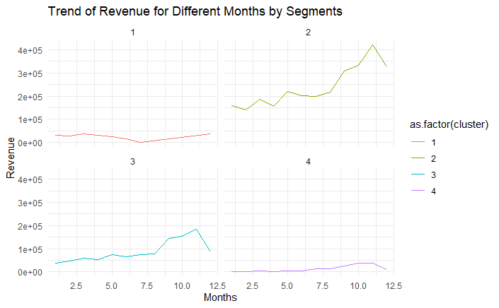

```r
# For Revenue
monthly_revenue_segmented <- clustered_new %>%
  group_by(month, cluster) %>%
  summarise(sum = sum(revenue))
ggplot(data = monthly_revenue_segmented, aes(x = month, y = sum, color = as.factor(cluster))) +
  geom_line() +
  labs(title = "Trend of Revenue for Different Months by Segments",
       x = "Months", y = "Revenue") +
  theme_minimal() +
  facet_wrap(~ cluster)
```

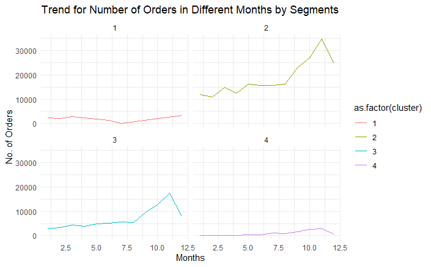

```r
# For Number of Orders
monthly_orders_segmented <- clustered_new %>%
  group_by(month, cluster) %>%
  summarise(sum = n())
ggplot(data = monthly_orders_segmented, aes(x = month, y = sum, color = as.factor(cluster))) +
  geom_line() +
  labs(title = "Trend for Number of Orders in Different Months by Segments",
       x = "Months", y = "No. of Orders") +
  theme_minimal() +
  facet_wrap(~ cluster)
```

[figure not shown]